# Western Redcedar (Cw)

Welcome to the Species Summary Dashboard, a place for species-specific summaries of the inputs and outputs of the Climate Change Informed Species Selection (CCISS) tool. This dashboard is intended to support forest practitioners, planners, and land managers, in making informed, forward-looking decisions about where tree species may be suitable to plant over the coming decades. As climate conditions shift, these decisions will become increasingly critical for maintaining productive, resilient, and adaptive forest landscapes.

At the top of the page, you will find tabs for the following summaries:

- **Reference (historical baseline) period**
  - Maps and descriptive summary of the species range in British Columbia during the baseline climate normal period of 1961–1990 in terms of its environmental suitability across Biogeoclimatic (BGC) zones and across three edatopic (soil nutrient x moisture) regimes, relative to the local biogeoclimatic subzone:
    - Poor/subxeric (B2)
    - Medium/mesic (C4)
    - Rich/hygric (D6)
- **CCISS projections**
  - A collection of visualizations and interpretations of the CCISS tool projections through 2100 for this species in British Columbia, exploring the changes in its suitable range over time. This includes:
    - Projected persistence and expansion of its suitable range relative to its historically suitable range
    - Shifts in its environmental suitability across the province and for each BGC zone
    - Shifts in its environmentally suitable area across the province and for each BGC zone
    - A summary of projected changes in particular areas of interest in BC (IN DEVELOPMENT)
    - Projected changes along elevational gradients (IN DEVELOPMENT)
- **Forest health**
  - A summary of forest health considerations and concerns for this species
- **References**
  - Bibliography of works cited
  - A collection of other tools, websites, and guides that provide additional information about this species, particularly covering background ecology and silvics information not summarized here

**Notes for Interpreting and Applying this Summary**

This dashboard is intended to provide a species-specific overview and interpretation of the data from the CCISS tool and does not represent management recommendations. Please see the [CCISS Documentation tab > Decision Guidance](https://bcgov-ffec.ca/cciss-docs/Decisions.html) section for more information on the appropriate and intended uses of these data.

[figure not shown]

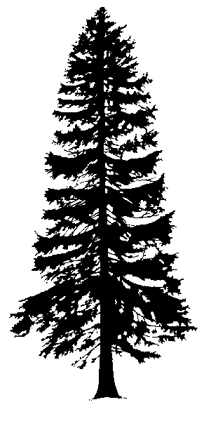

Western Redcedar (*Thuja plicata*)

**Western redcedar (abbreviated as Cw) is a species with high ecological, cultural, and economic value. The CCISS projections for Cw reveal a complex pattern: potential expansion of suitability upwards in elevation and into more northern areas, and localized declines in low-elevation and drought-prone regions.**

While the CCISS tool offers valuable insights into broad-scale trends, summarized here by species, suitability projections must be interpreted with caution. Many areas of projected change are also areas with high uncertainty in climate predictions. Furthermore, factors such as soil texture, drainage, land-use history, forest health pressures, and biotic interactions (e.g., competition or browsing) can strongly influence actual outcomes on the ground. These nuances emphasize the importance of pairing climate tools with on-the-ground knowledge and site-specific judgement when planning future western redcedar management.

**Species geographic and climatic range**

Western redcedar (Cw) is native to the Pacific Northwest of North America, with a broad geographic range extending from northern California, through Oregon, Washington, and British Columbia, into southeastern Alaska. Eastward, it extends as far inland as the western slopes of the Rocky Mountains in Montana and Idaho.

Western redcedar is best adapted to climates with abundant precipitation and high humidity but can tolerate a range of conditions. In BC, Cw is most commonly found in cool and cold mesothermal climates on the coast and in montane continental cool temperate climates in the interior wet belt (Klinka & Brisco, 2009). The species grows across a wide variety of soil types, but is most productive on fresh to moist, nutrient-rich soils (Klinka & Brisco, 2009).

In British Columbia, western redcedar is found in two distinct populations: a coastal population, and an interior population. Approximately 81% of the province’s mature Cw volume is found in the coastal population (Klinka & Brisco, 2009). These two populations are ecologically distinct due to differences in climatic regimes, topography, and associated vegetation, but genetically, they are quite similar (Klinka & Brisco, 2009). It is common for western redcedar to co-occur on mesic and wet sites with western hemlock (*Tsuga heterophylla*) throughout its range in BC.

**Species environmental suitability during the reference period (1961–1990)**

In the maps below, each colour represents the species environmental suitability during the historical reference period* of 1961–1990 as determined by expert ratings. Green represents a high suitability (E1 rating), blue represents moderate suitability (E2), yellow represents low suitability (E3), and white indicates areas that are unsuitable for the species. See [CCISS Documentation tab > Methods > Environmental Suitability Ratings](https://bcgov-ffec.ca/cciss-docs/Methods.html#environmental-suitability-ratings) for more detailed definitions and information on the expert rating process.

*Note on terminology: The historical reference period is sometimes referred to as the “baseline” or simply “historical” or “reference” period.

**Medium/mesic (C4)**

Environmental suitability on medium/mesic sites (C4 edatope) under baseline climate (1961–1990)

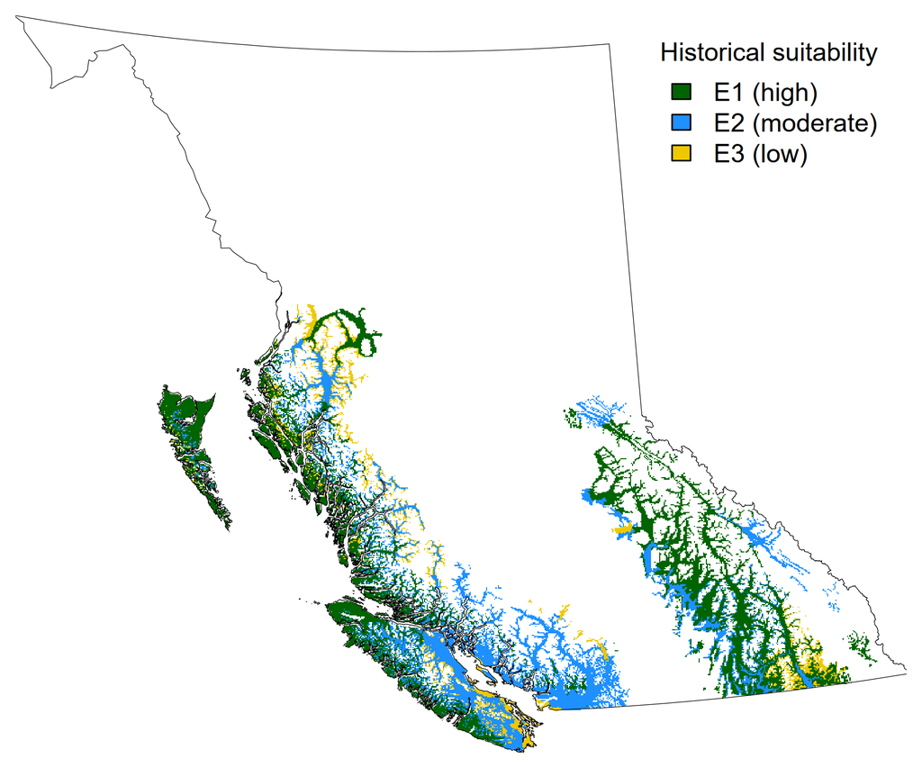

Environmental suitability for Cw is high (E1) in most of the medium/mesic edatopes within its range. Suitability drops to E2 or E3 in the drier BGC subzones (e.g., the CDFmm and CWHdm subzones along the Strait of Georgia and surrounding low-elevation areas of its drainage basin).

**Poor/subxeric (B2)**

Environmental suitability in poor/subxeric sites (B2 edatope) under baseline climate (1961–1990)

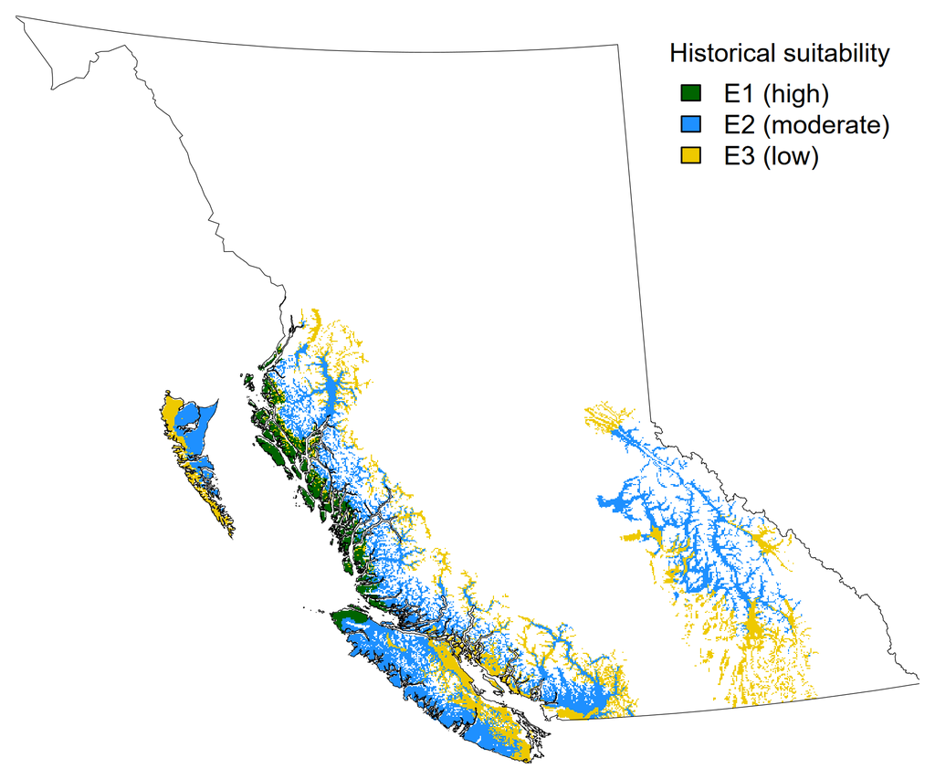

In poor/subxeric edatopes, the environmental suitability for Cw tends to be moderate to low, and only high in BGC subzones that are relatively wet overall (e.g., the CWHvh2 site series along the central coast).

**Rich/hygric (D6)**

Environmental suitability in rich/hygric sites (D6 edatope) under baseline climate (1961–1990)

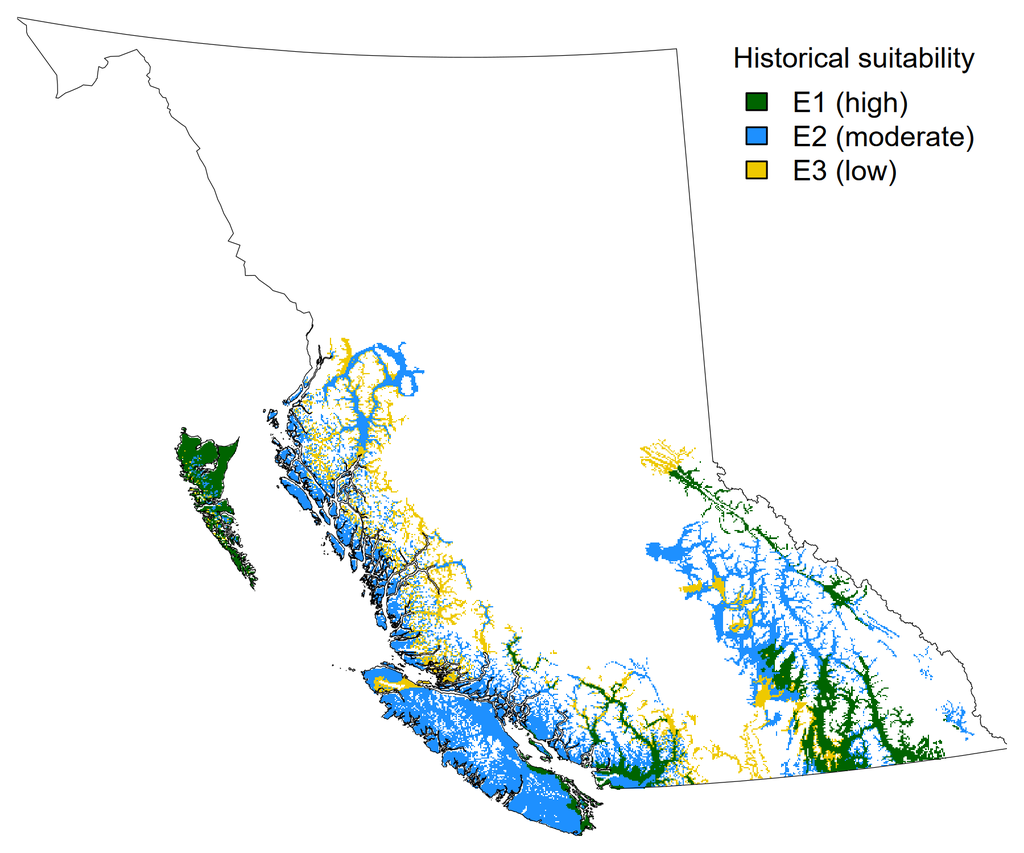

The environmental suitability of Cw is high (E1) in the rich/hygric edatopes of drier subzones (e.g., CWHdm in the lower mainland) but then decreases to E2 or E3 in very wet subzone variants (as in CWHvh2 along the central coast). However, in other very wet subzone variants, its suitability remains high (e.g., CWHvh3 and CWHwh1 on Haida Gwaii). In more xeric subzones of its range (e.g., IDFxh1 and PPxh1 in the Okanagan valley), rich/hygric edatopes only provide pockets of low environmental suitability.

**Distribution of Cw across BGC zones**

The pie chart to the right depicts the distribution of the total environmentally suitable area of western redcedar in BC by biogeoclimatic (BGC) zone, based on the climate of the historical reference period (1961–1990).

On the coast, western redcedar is most abundant in the Coastal Western Hemlock (CWH) zone, especially on mesic to wet sites, where it grows alongside Douglas-fir, grand fir, and bigleaf maple (Egan, 1999). It also occurs, though less frequently, in the Coastal Douglas-fir (CDF) zone and in the lower elevation of the Mountain Hemlock (MH) zones, where it tends to be subdominant or scattered.

In the interior, it is a key species in the Interior Cedar-Hemlock (ICH) zone, particularly in the wetter subzones of southeastern and central British Columbia, and in the Interior Douglas-fir (IDF) zone, although typically as a minor component. It can also occasionally be found in the wetter subzones of the Sub-Boreal Spruce (SBS), Montane Spruce (MS), Ponderosa Pine (PP), and lower Engelmann Spruce – Subalpine Fir (ESSF) zones ([Government of British Columbia 2025](https://www2.gov.bc.ca/gov/content/industry/forestry/managing-our-forest-resources/silviculture/tree-species-selection/tree-species-compendium-index/western-redcedar)).

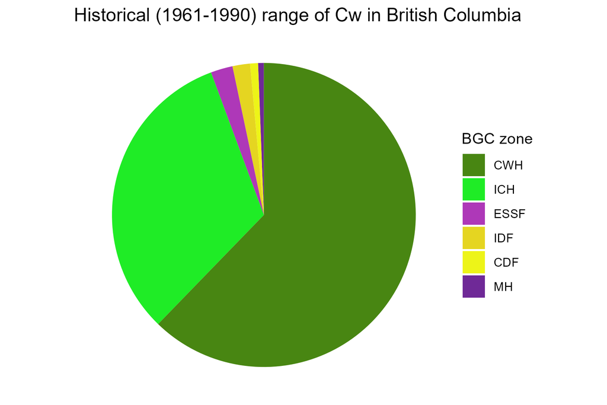

**Key to BGC zones:** [CCISS Documentation > Definitions](https://bcgov-ffec.ca/cciss-docs/Definitions.html#biogeoclimatic-ecosystem-classification-bec-codes)

**Future projected environmental suitability for western redcedar**

On this page, you will find a visual and interpretive synthesis of the environmental suitability projections calculated using the Climate Change Informed Species Selection [CCISS](https://bcgov-ffec.ca/cciss-docs/) tool, including:

1. Proportion of the historic range that the species is predicted to remain environmentally suitable (i.e. persist) or become newly suitable (i.e. expand) by site type (edatope).
2. Predicted mean changes in environmental suitability across its geographic range in BC, by future time period and site type (edatope).
3. Predicted shifts in total suitable area over time across the province and by biogeoclimatic (BGC) zone.

**Broad trends**

Overall, western redcedar is projected to persist within about 40–60% of its historically suitable range, while its suitable range is projected to expand over time, to be about 1–1.5 times larger than the historically suitable range. Expansion of Cw’s suitable area is projected to be driven by higher temperatures expected under increased warming scenarios, particularly in wetter site types (D6).

*Notes on interpretation of persistence and expansion*

Persistence (x-axis) and expansion (y-axis) are subtly different in how they relate to the historical range of the species. Persistence describes the change in environmental suitability within the species historical range. While Expansion describes the change in environmental suitability outside of the species historical range. Calculated as follows:

$$\text{Persistence (\%)} =
\frac{\text{future suitable area within historical range of suitability}}
{\text{historically suitable area}}
\times 100$$
$$\text{Expansion (\%)} =
\frac{\text{future suitable area outside historical range of suitability}}
{\text{historically suitable area}}
\times 100$$

**Medium/mesic (C4)**

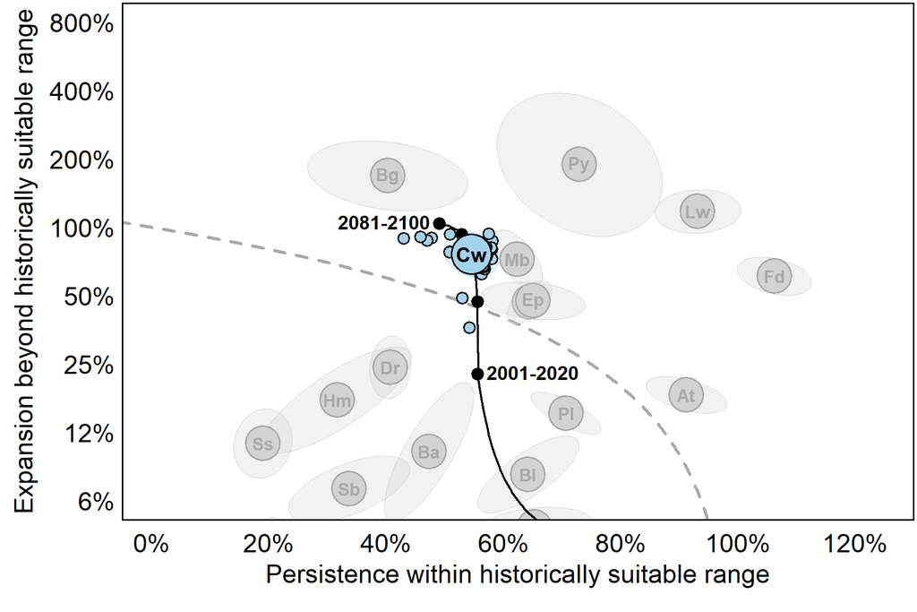

This figure shows the overall projected persistence and expansion of the suitable range of western redcedar in the SSP2–4.5 emission scenario given current policies for moderate emission mitigation. The black line shows the projected trajectory of change over time for this species, with black points representing an average for each time period. The first and last time periods are labeled, and the model results for the 2041–2060 period are depicted in blue due to the relevance of this time period for management planning. The small blue points represent simulation runs of the various global climate models (GCMs) used in the CCISS projections (Mahony et al., 2022). The large blue point with the species abbreviation is the mean of the entire GCM ensemble for an edatope averaged across all BGC zones in the province. Other species are shown for reference in the background, as grey mean points and shaded ellipses representing the 1-standard deviation probability of the ensemble calculated for each point. The grey dashed line divides areas of the plot for which total suitable area is either growing (above the line) or shrinking (below the line). Note that all results exclude biogeoclimatic units that do not currently support commercially operable forest, and that expansion (the y-axis) is log-scaled. Because an edatope is relative to each BGC, differences among edatope tabs should not be compared absolutely but rather within the context of their regional climate(s) (e.g., a mesic site in a Coastal Western Hemlock (CWH) subzone is relatively wetter than a mesic site in an Interior Douglas-fir (IDF) subzone).

**Poor/subxeric (B2)**

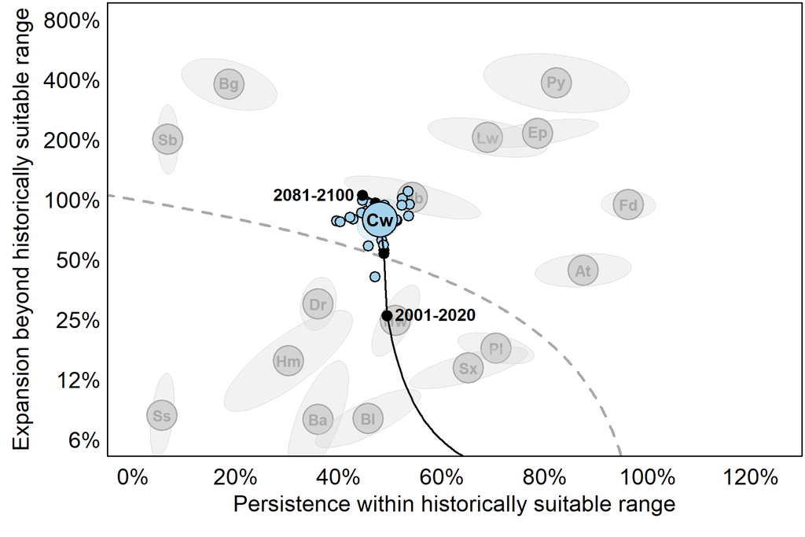

This figure shows the overall projected persistence and expansion of the suitable range of western redcedar in the SSP2–4.5 emission scenario given current policies for moderate emission mitigation. The black line shows the projected trajectory of change over time for this species, with black points representing an average for each time period. The first and last time periods are labeled, and the model results for the 2041–2060 period are depicted in blue due to the relevance of this time period for management planning. The small blue points represent simulation runs of the various global climate models (GCMs) used in the CCISS projections (Mahony et al., 2022). The large blue point with the species abbreviation is the mean of the entire GCM ensemble for an edatope averaged across all BGC zones in the province. Other species are shown for reference in the background, as grey mean points and shaded ellipses representing the 1-standard deviation probability of the ensemble calculated for each point. The grey dashed line divides areas of the plot for which total suitable area is either growing (above the line) or shrinking (below the line). Note that all results exclude biogeoclimatic units that do not currently support commercially operable forest, and that expansion (the y-axis) is log-scaled. Because an edatope is relative to each BGC, differences among edatope tabs should not be compared absolutely but rather within the context of their regional climate(s) (e.g., a mesic site in a Coastal Western Hemlock (CWH) subzone is relatively wetter than a mesic site in an Interior Douglas-fir (IDF) subzone).

**Rich/hygric (D6)**

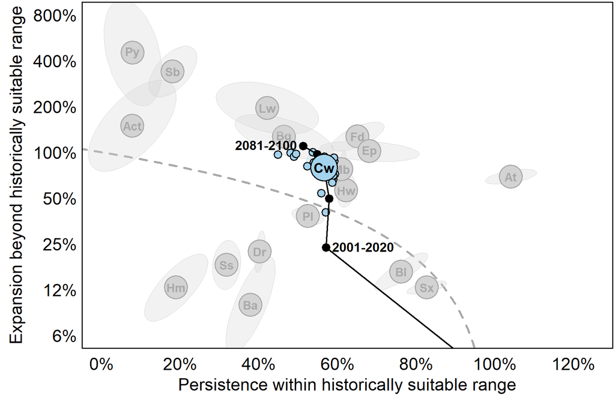

This figure shows the overall projected persistence and expansion of the suitable range of western redcedar in the SSP2–4.5 emission scenario given current policies for moderate emission mitigation. The black line shows the projected trajectory of change over time for this species, with black points representing an average for each time period. The first and last time periods are labeled, and the model results for the 2041–2060 period are depicted in blue due to the relevance of this time period for management planning. The small blue points represent simulation runs of the various global climate models (GCMs) used in the CCISS projections (Mahony et al., 2022). The large blue point with the species abbreviation is the mean of the entire GCM ensemble for an edatope averaged across all BGC zones in the province. Other species are shown for reference in the background, as grey mean points and shaded ellipses representing the 1-standard deviation probability of the ensemble calculated for each point. The grey dashed line divides areas of the plot for which total suitable area is either growing (above the line) or shrinking (below the line). Note that all results exclude biogeoclimatic units that do not currently support commercially operable forest, and that expansion (the y-axis) is log-scaled. Because an edatope is relative to each BGC, differences among edatope tabs should not be compared absolutely but rather within the context of their regional climate(s) (e.g., a mesic site in a Coastal Western Hemlock (CWH) subzone is relatively wetter than a mesic site in an Interior Douglas-fir (IDF) subzone).

**Suitability changes**

Overall, the total suitable area in BC for western redcedar is projected to increase with climate change, but the specific locations where it is most suitable will shift.

The most notable pattern observed is in the interior of BC, with expansion of Cw suitability into the sub-boreal, as ICH (Interior Cedar – Hemlock)-like climates are projected to spread northward and westward into the historic Sub-Boreal Spruce (SBS) zone. Under historical climate (1961–1990), the Interior Plateau, including the area between Smithers and Prince George, was unsuitable for Cw. CCISS projections suggest that much of this area will become moderately to highly environmentally suitable (E1 to E2) for Cw by 2100.

In addition, locations in the southeast of the province that were historically Engelmann Spruce – Subalpine Fir (ESSF) or Montane Spruce (MS) zones, are predicted to become more climatically like ICH zones, making them newly suitable for western redcedar. As these are two zones that are upslope of Cw’s current range, this means that higher elevation areas will become more environmentally suitable for Cw over time. This newly suitable area comes alongside significant declines to complete loss of Cw suitability projected in lower elevation, valley bottoms of this region (historically ICHxw and ICHdw subzones).

In the southwest of the province, similar losses of Cw suitability in valley bottoms are projected in CWHdm, CwHds subzones around Vancouver, Squamish and east into the Fraser Valley.

These patterns are shown in 20-year intervals and by edatopic space in the figures to the right.

**Medium/mesic (C4)**

**2001–2020**

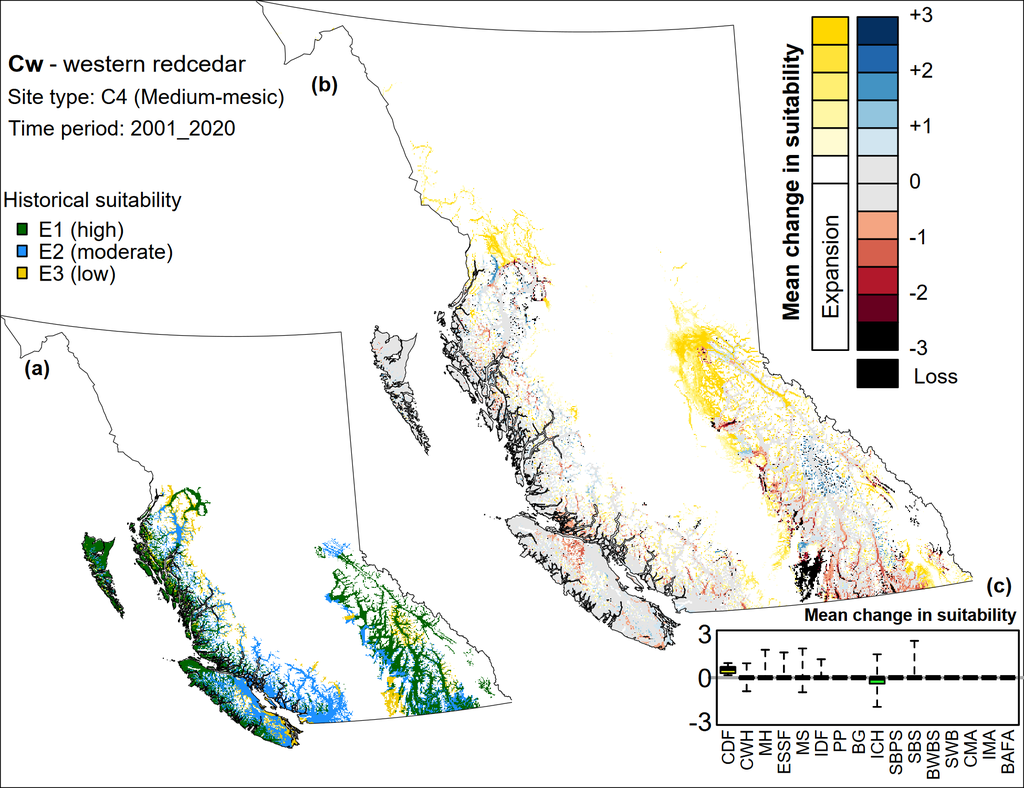

a) Historical environmental suitability rating during the reference period of 1961–1990 as determined by expert ratings.  
b) Mean change in suitability from the reference period, with shades of yellow representing areas of new suitability, blue shades representing increased suitability, red shades representing decreased suitability, and black representing a complete loss of suitability.  
c) Mean changes in suitability ranking by BGC zone; boxplot whiskers extend to the 5th and 95th percentiles.

**2021–2040**

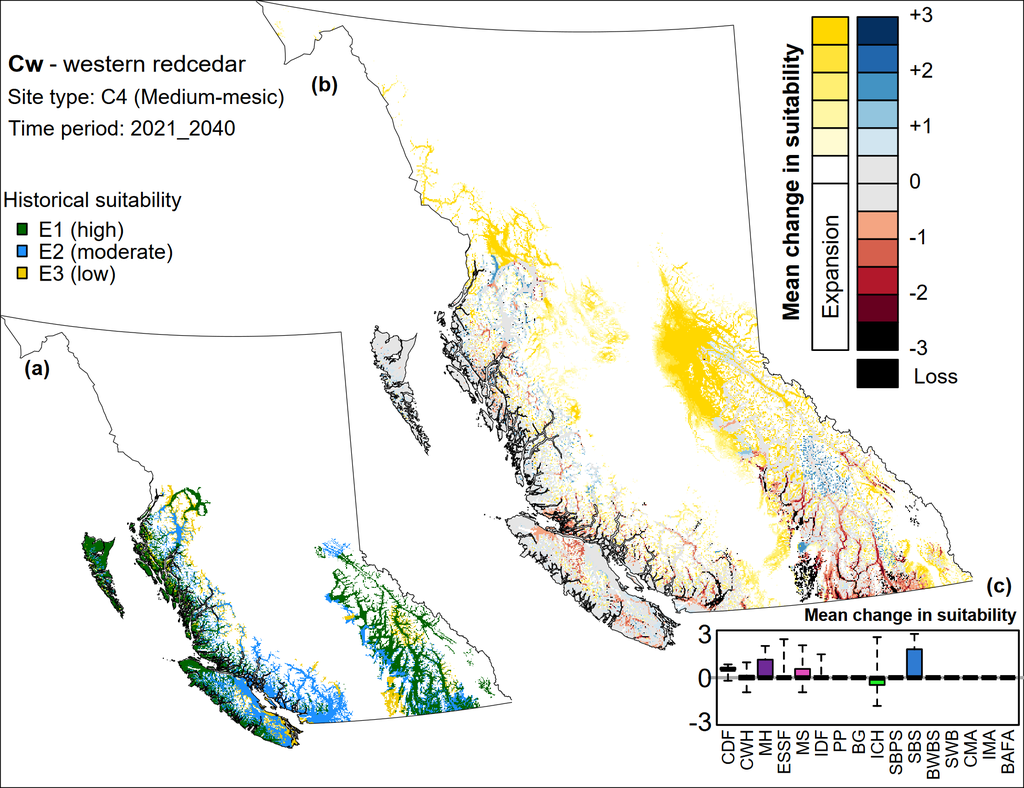

a) Historical environmental suitability rating during the reference period of 1961–1990 as determined by expert ratings.  
b) Mean change in suitability from the reference period, with shades of yellow representing areas of new suitability, blue shades representing increased suitability, red shades representing decreased suitability, and black representing a complete loss of suitability.  
c) Mean changes in suitability ranking by BGC zone; boxplot whiskers extend to the 5th and 95th percentiles.

**2041–2060**

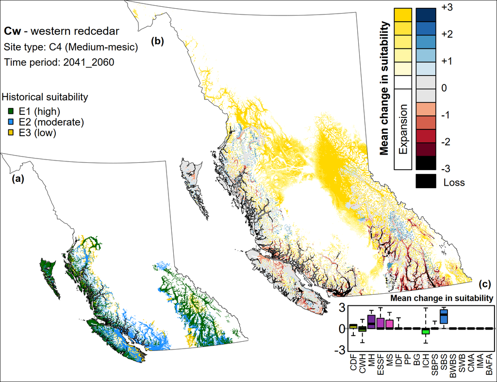

a) Historical environmental suitability rating during the reference period of 1961–1990 as determined by expert ratings.  
b) Mean change in suitability from the reference period, with shades of yellow representing areas of new suitability, blue shades representing increased suitability, red shades representing decreased suitability, and black representing a complete loss of suitability.  
c) Mean changes in suitability ranking by BGC zone; boxplot whiskers extend to the 5th and 95th percentiles.

**2061–2080**

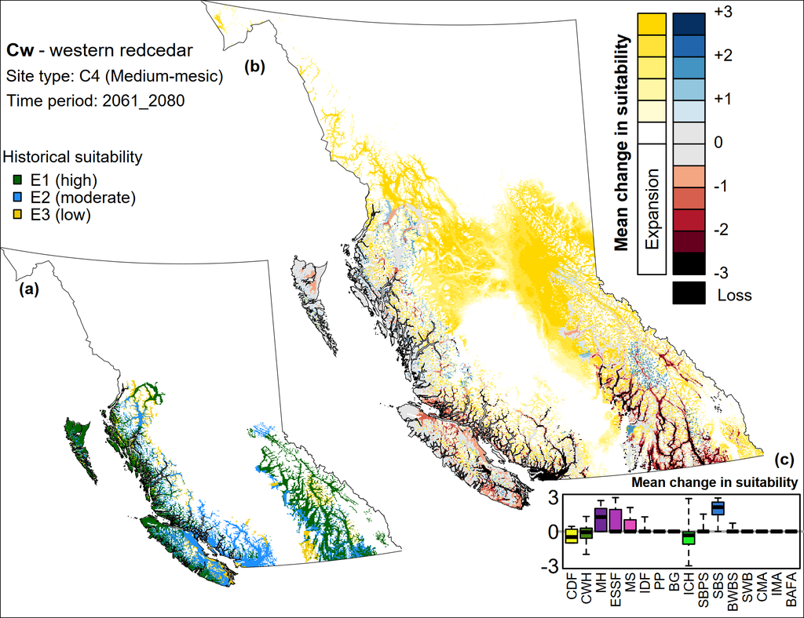

a) Historical environmental suitability rating during the reference period of 1961–1990 as determined by expert ratings.  
b) Mean change in suitability from the reference period, with shades of yellow representing areas of new suitability, blue shades representing increased suitability, red shades representing decreased suitability, and black representing a complete loss of suitability.  
c) Mean changes in suitability ranking by BGC zone; boxplot whiskers extend to the 5th and 95th percentiles.

**2081–2100**

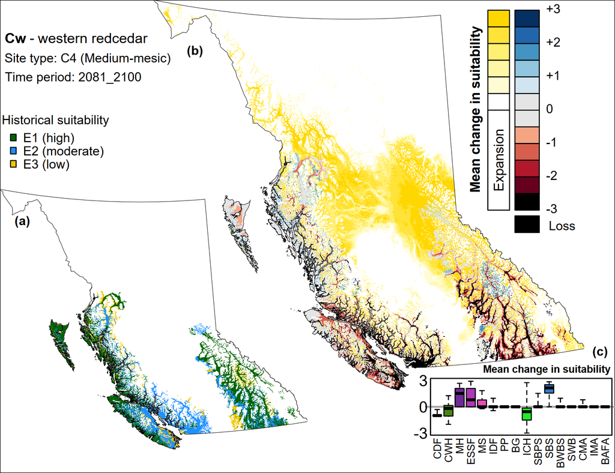

a) Historical environmental suitability rating during the reference period of 1961–1990 as determined by expert ratings.  
b) Mean change in suitability from the reference period, with shades of yellow representing areas of new suitability, blue shades representing increased suitability, red shades representing decreased suitability, and black representing a complete loss of suitability.  
c) Mean changes in suitability ranking by BGC zone; boxplot whiskers extend to the 5th and 95th percentiles.

**Poor/subxeric (B2)**

**2001–2020**

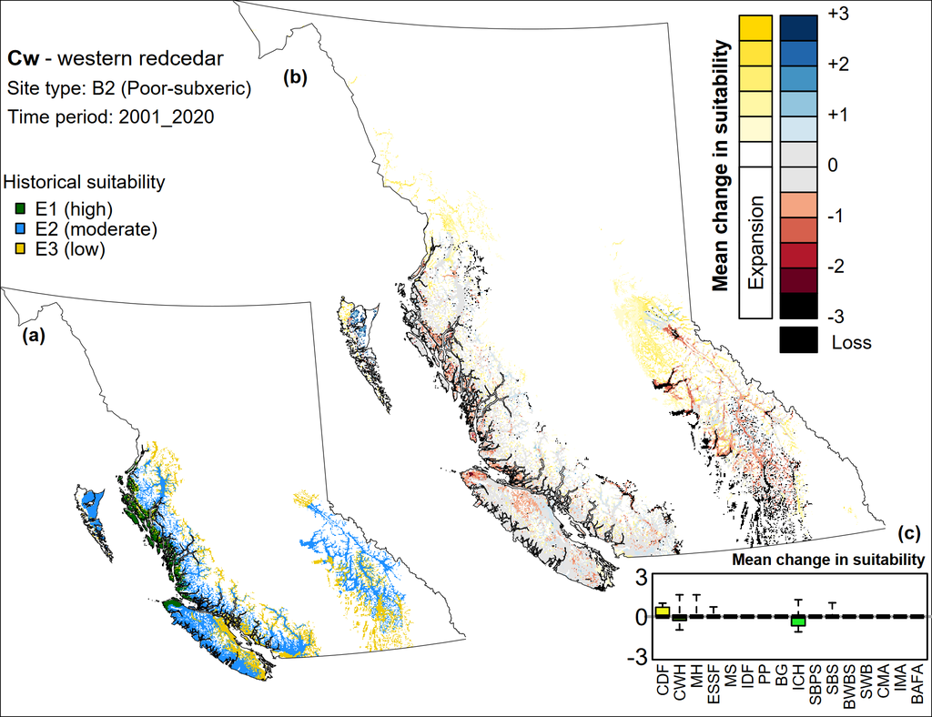

a) Historical environmental suitability rating during the reference period of 1961–1990 as determined by expert ratings.  
b) Mean change in suitability from the reference period, with shades of yellow representing areas of new suitability, blue shades representing increased suitability, red shades representing decreased suitability, and black representing a complete loss of suitability.  
c) Mean changes in suitability ranking by BGC zone; boxplot whiskers extend to the 5th and 95th percentiles.

**2021–2040**

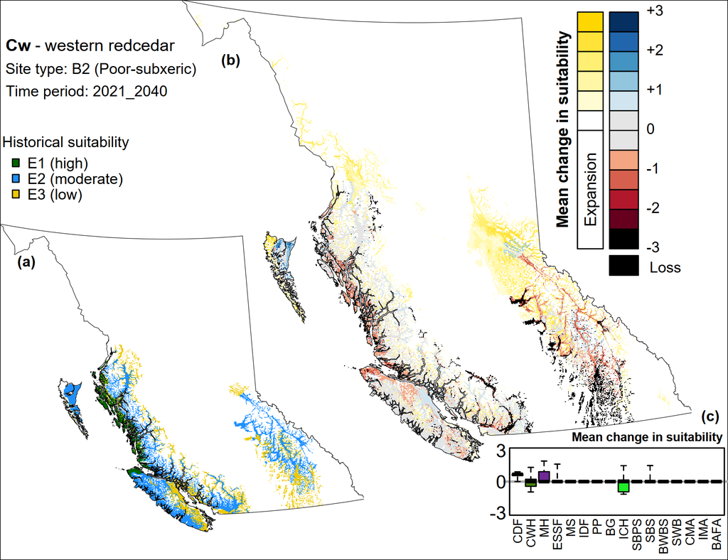

a) Historical environmental suitability rating during the reference period of 1961–1990 as determined by expert ratings.  
b) Mean change in suitability from the reference period, with shades of yellow representing areas of new suitability, blue shades representing increased suitability, red shades representing decreased suitability, and black representing a complete loss of suitability.  
c) Mean changes in suitability ranking by BGC zone; boxplot whiskers extend to the 5th and 95th percentiles.

**2041–2060**

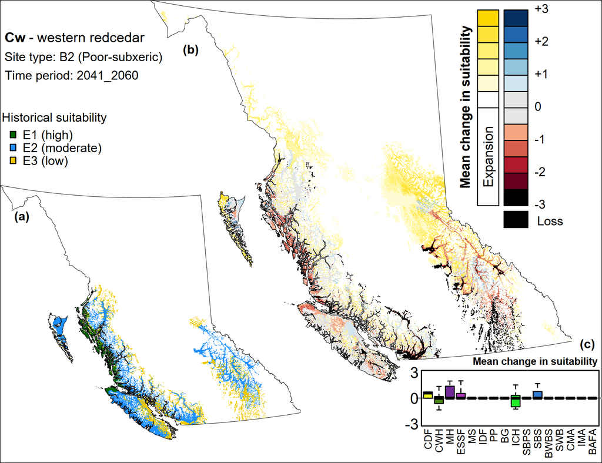

a) Historical environmental suitability rating during the reference period of 1961–1990 as determined by expert ratings.  
b) Mean change in suitability from the reference period, with shades of yellow representing areas of new suitability, blue shades representing increased suitability, red shades representing decreased suitability, and black representing a complete loss of suitability.  
c) Mean changes in suitability ranking by BGC zone; boxplot whiskers extend to the 5th and 95th percentiles.

**2061–2080**

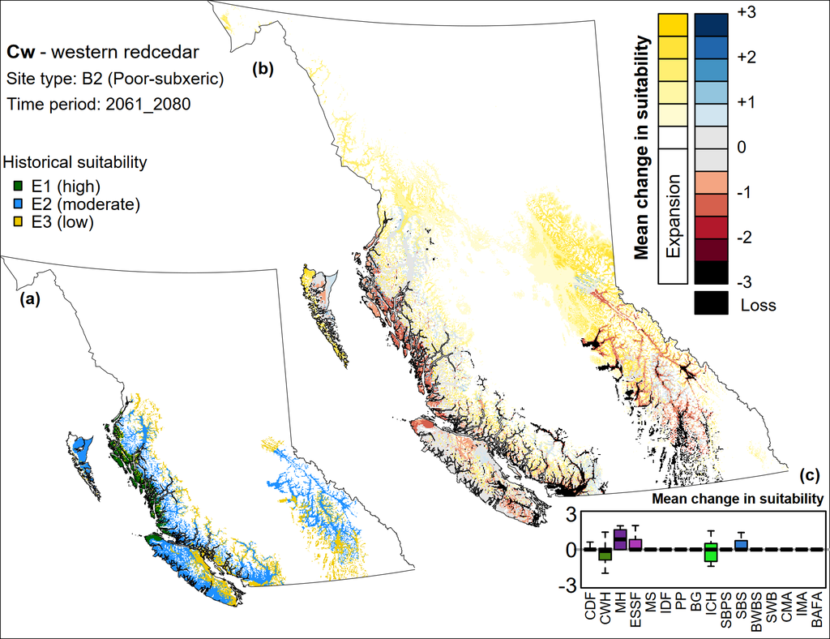

a) Historical environmental suitability rating during the reference period of 1961–1990 as determined by expert ratings.  
b) Mean change in suitability from the reference period, with shades of yellow representing areas of new suitability, blue shades representing increased suitability, red shades representing decreased suitability, and black representing a complete loss of suitability.  
c) Mean changes in suitability ranking by BGC zone; boxplot whiskers extend to the 5th and 95th percentiles.

**2081–2100**

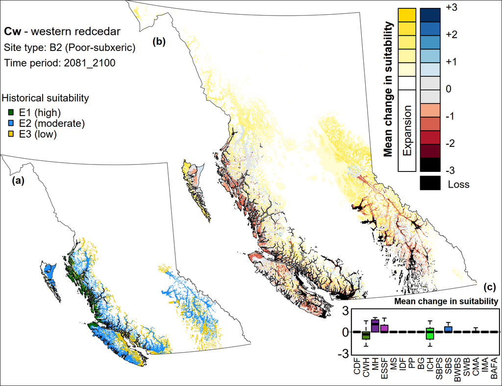

a) Historical environmental suitability rating during the reference period of 1961–1990 as determined by expert ratings.  
b) Mean change in suitability from the reference period, with shades of yellow representing areas of new suitability, blue shades representing increased suitability, red shades representing decreased suitability, and black representing a complete loss of suitability.  
c) Mean changes in suitability ranking by BGC zone; boxplot whiskers extend to the 5th and 95th percentiles.

**Rich/hygric (D6)**

**2001–2020**

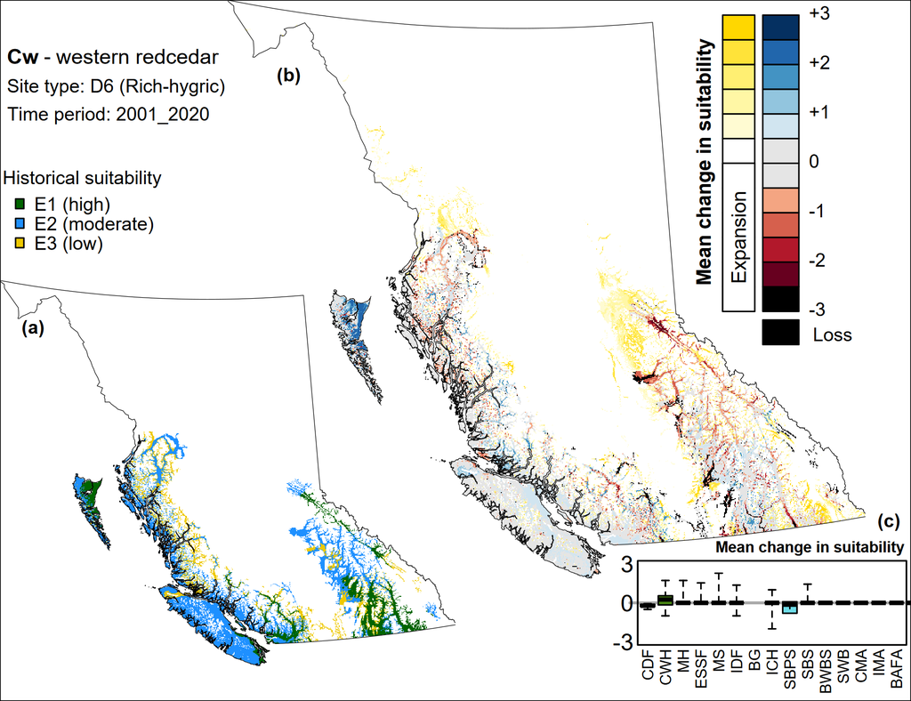

a) Historical environmental suitability rating during the reference period of 1961–1990 as determined by expert ratings.  
b) Mean change in suitability from the reference period, with shades of yellow representing areas of new suitability, blue shades representing increased suitability, red shades representing decreased suitability, and black representing a complete loss of suitability.  
c) Mean changes in suitability ranking by BGC zone; boxplot whiskers extend to the 5th and 95th percentiles.

**2021–2040**

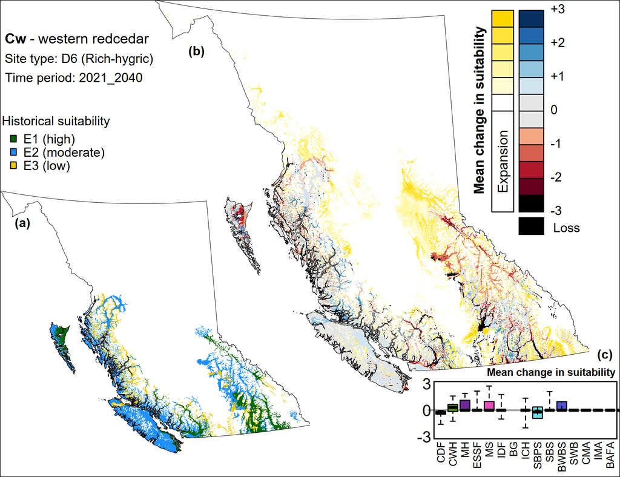

a) Historical environmental suitability rating during the reference period of 1961–1990 as determined by expert ratings.  
b) Mean change in suitability from the reference period, with shades of yellow representing areas of new suitability, blue shades representing increased suitability, red shades representing decreased suitability, and black representing a complete loss of suitability.  
c) Mean changes in suitability ranking by BGC zone; boxplot whiskers extend to the 5th and 95th percentiles.

**2041–2060**

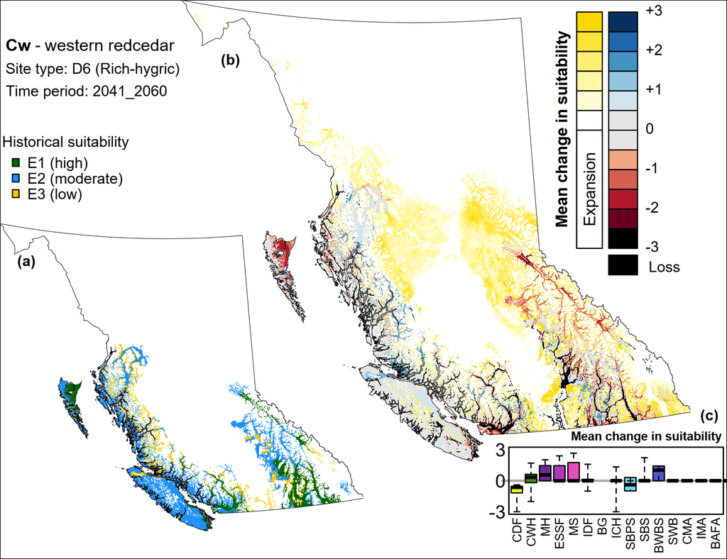

a) Historical environmental suitability rating during the reference period of 1961–1990 as determined by expert ratings.  
b) Mean change in suitability from the reference period, with shades of yellow representing areas of new suitability, blue shades representing increased suitability, red shades representing decreased suitability, and black representing a complete loss of suitability.  
c) Mean changes in suitability ranking by BGC zone; boxplot whiskers extend to the 5th and 95th percentiles.

**2061–2080**

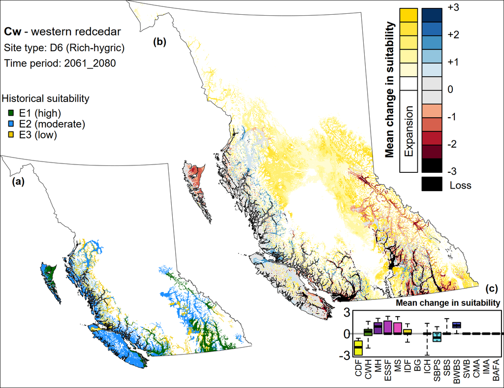

a) Historical environmental suitability rating during the reference period of 1961–1990 as determined by expert ratings.  
b) Mean change in suitability from the reference period, with shades of yellow representing areas of new suitability, blue shades representing increased suitability, red shades representing decreased suitability, and black representing a complete loss of suitability.  
c) Mean changes in suitability ranking by BGC zone; boxplot whiskers extend to the 5th and 95th percentiles.

**2081–2100**

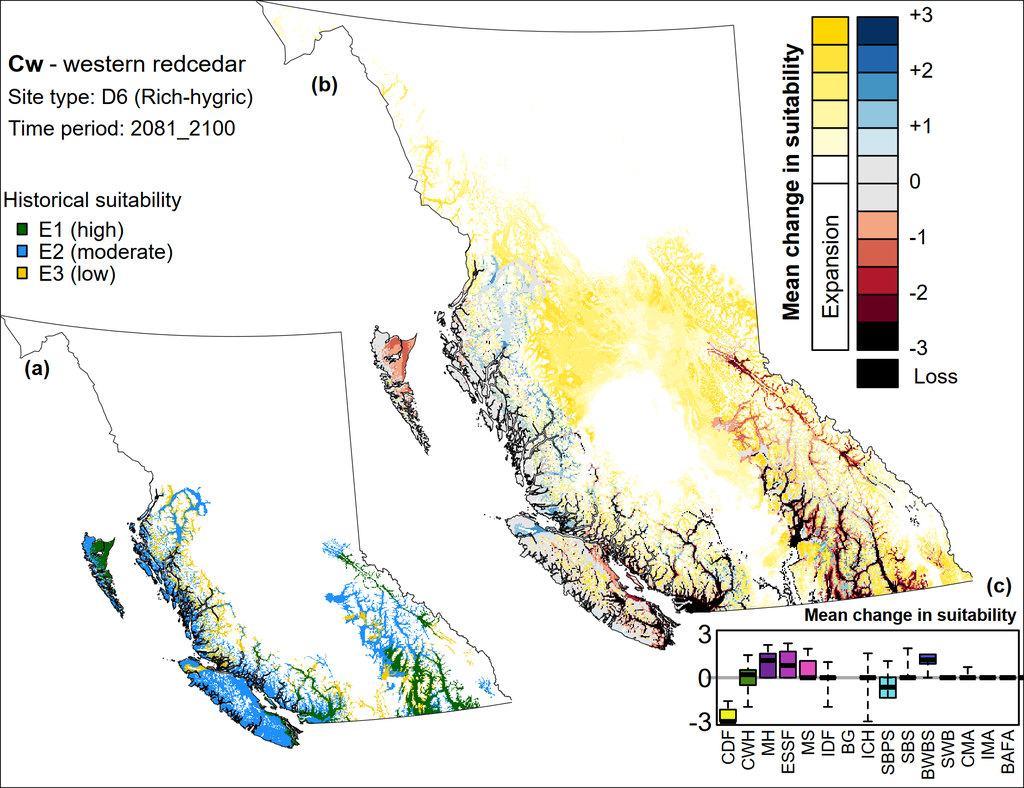

a) Historical environmental suitability rating during the reference period of 1961–1990 as determined by expert ratings.  
b) Mean change in suitability from the reference period, with shades of yellow representing areas of new suitability, blue shades representing increased suitability, red shades representing decreased suitability, and black representing a complete loss of suitability.  
c) Mean changes in suitability ranking by BGC zone; boxplot whiskers extend to the 5th and 95th percentiles.

**Shifts in suitable area**

**Medium/mesic (C4)**

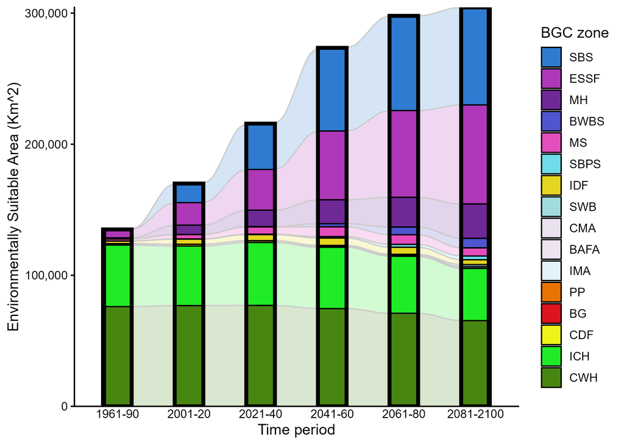

This figure shows the projected changes in western redcedar’s suitable area in BC (km<sup>2</sup>) over time by biogeoclimatic zone (colours) within the three representative site types/edatopes (tabs). The first time period shown on the left of each graph is the historical reference period (1961–1990), where environmental suitability is determined by expert ratings. Subsequent time periods are based on CCISS model projections incorporating environmental suitability (from the reference period) and future climate data. For future projected time periods, the relative areas of BGC zones remain static within the province i.e., they are not shrinking or growing). Rather, this figure reflects changes in the projected spatial distribution of climate types that may be more or less suitable for the focal species, representing changes in suitable area across these static zones (e.g., SBS climate becoming more ‘ICH-like’ which makes it suitable for Cw).

**Key to BGC zones:** [CCISS Documentation > Definitions](https://bcgov-ffec.ca/cciss-docs/Definitions.html#biogeoclimatic-ecosystem-classification-bec-codes)

**Poor/subxeric (B2)**

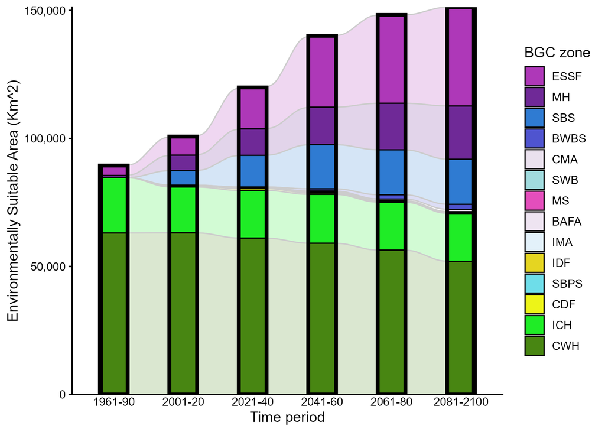

This figure shows the projected changes in western redcedar’s suitable area in BC (km<sup>2</sup>) over time by biogeoclimatic zone (colours) within the three representative site types/edatopes (tabs). The first time period shown on the left of each graph is the historical reference period (1961–1990), where environmental suitability is determined by expert ratings. Subsequent time periods are based on CCISS model projections incorporating environmental suitability (from the reference period) and future climate data. For future projected time periods, the relative areas of BGC zones remain static within the province (i.e., they are not shrinking or growing). Rather, this figure reflects changes in the projected spatial distribution of climate types that may be more or less suitable for the focal species, representing changes in suitable area across these static zones (e.g., SBS climate becoming more ‘ICH-like’ which makes it suitable for Cw).

**Key to BGC zones:** [CCISS Documentation > Definitions](https://bcgov-ffec.ca/cciss-docs/Definitions.html#biogeoclimatic-ecosystem-classification-bec-codes)

**Rich/hygric (D6)**

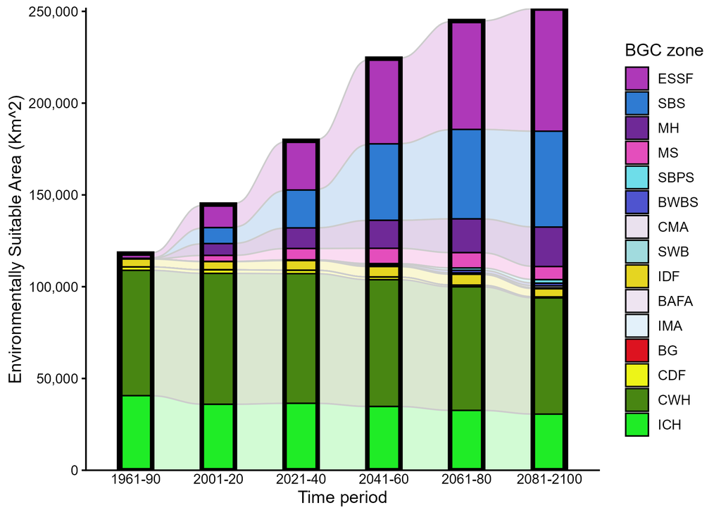

This figure shows the projected changes in western redcedar’s suitable area in BC (km<sup>2</sup>) over time by biogeoclimatic zone (colours) within the three representative site types/edatopes (tabs). The first time period shown on the left of each graph is the historical reference period (1961–1990), where environmental suitability is determined by expert ratings. Subsequent time periods are based on CCISS model projections incorporating environmental suitability (from the reference period) and future climate data. For future projected time periods, the relative areas of BGC zones remain static within the province (i.e., they are not shrinking or growing). Rather, this figure reflects changes in the projected spatial distribution of climate types that may be more or less suitable for the focal species, representing changes in suitable area across these static zones (e.g., SBS climate becoming more ‘ICH-like’ which makes it suitable for Cw).

**Key to BGC zones:** [CCISS Documentation > Definitions](https://bcgov-ffec.ca/cciss-docs/Definitions.html#biogeoclimatic-ecosystem-classification-bec-codes)

In general, western redcedar’s total suitable area is projected to expand across BC over the 21st century, with increases in suitable area in SBS, ESSF, and MH zones, and relatively stable to slight declines in suitable area in the CWH and ICH zones.

Many mapped units within the Sub-Boreal Spruce (SBS) zone, especially wetter subzone/variants, are projected to become warmer and wetter over time, shifting towards more Interior Cedar-Hemlock (ICH)-like climates in the future. This likely explains Cw’s projected expansion of suitable area into the SBS zone, as well as small portions of the BWBS and SBPS zones. Similarly, wet variants in the lower elevation portions of the Enegelmann Spruce-Subalpine Fir (ESSF) zone are also projected to undergo shifts toward more ICH-like climates, which means that the increased suitable area projected for Cw in this higher-elevation zone may lead to up-slope movement of the species. The Mountain Hemlock (MH) zone is above the CWH zone in elevation throughout the Coast mountains and historically supported small populations of Cw at lower elevations of the zone. Warming temperatures are the likely driver of increases in suitable area for Cw projected at higher elevation into the MH zone.

These broad patterns are generally consistent across site types, with more pronounced increases in suitable area in the SBS zone for medium/mesic (C4) site types, and for ESSF zones in poor/subxeric B2, and rich/hygric D6 site types.

**Biotic factors**

Redcedar is generally more resistant to pests and pathogens than other timber species (Klinka & Brisco, 2009). However, opportunistic biotic agents can take advantage of already stressed trees. Cedar leaf blight (*Didyamascella thujina*) is the most severe pathogen currently affecting redcedar. Infecting leaflets of seedlings and mature trees, it causes gradual decrease in growth through a loss of photosynthetic area, eventually leading to tree death (Aldana et al., 2023). This pathogen is most common in dense stands with high humidity (Klinka & Brisco, 2009). The prevalence of and damage associated with cedar leaf blight is projected to increase under future climate scenarios (Aldana et al., 2023). Since genetic factors appear to influence susceptibility, selecting or breeding for resistance could be important in future management strategies for cedar leaf blight (Aldana et al., 2023).

Several species of heart- and butt-rotting fungi have long been associated with mature redcedar, including brown cubical pocket and butt rot (*Poria asiatica*), white ring rot (*Poria albipellucida*), white pitted trunk rot (*Fomes pini*), brown crumbly butt rot (*Merulius* spp.), and spongy white rot (*Poria subacida*, summarized in Seebacher (2007)). To a lesser extent, *Armillaria ostoyae* (Armillaria root disease) and *Phellinus weirii* (laminated root rot) can also afflict redcedar trees.

Few insects are known to attack redcedar directly. These include the western cedar borer (*Trachykele blondeli*, also known as the powderworm), the western cedar bark beetle (*Phloeosinus punctatus*), and the hemlock looper (*Lambdina fiscellaria lugubrosa*), which feeds broadly on conifer foliage (summarized in Seebacher (2007)).

For more information see the [Forest Guide to Tree Health](https://www2.gov.bc.ca/assets/gov/farming-natural-resources-and-industry/forestry/forest-health/forest-health-docs/field_guide_to_forest_damage_in_bc_web.pdf).

**Western redcedar dieback**

Widespread western redcedar dieback has been documented throughout the southern portion of the species’ range (Andrus et al., 2023), particularly in Washington state and southwestern British Columbia (Georgia Depression). This dieback is, at least in part, driven by drought, extreme heat events, and exacerbated by consecutive drought events without adequate recovery time.

Dieback in redcedar is typically identified through a range of visible canopy symptoms. The most commonly reported indicators include thinning or death of the live crown (top kill), foliage yellowing (chlorosis), branch die-off (flagging), thinning, and in some cases, complete tree mortality. Trees may also exhibit increased cone production, which has been interpreted as a possible stress response. These symptoms often occur in the absence of obvious biotic agents, and are instead linked to environmental stressors, particularly drought and heat.

Since 2015, a pronounced increase in reports and field observations suggests that dieback is becoming more widespread in low-elevation coastal forests. A significant pulse of mortality was reported around 2017-2018, affecting forests from the Willamette Valley in Oregon, through western Washington, and into southern British Columbia (McWilliams, 2024). Similar reports come from southeastern Vancouver Island and parts of the lower mainland (Tomaszewski, 2022).

The causes of redcedar dieback are increasingly understood to be multi-factorial, with climate water stress emerging as the dominant driver across most affected regions. While exact mechanism may vary by site and context, evidence consistently points toward seasonal drought, elevated temperatures, and increased vapor pressure deficit (VPD)—particularly during late spring and early summer—as key stressors contributing to decline and mortality.

Redcedar mortality is often associated with multiple consecutive years of water deficit, which leads to compounded physiological stress. Redcedar can recover from a single year of drought if followed by cooler, wetter conditions in subsequent years, but recovery slowed or failed when drought persisted across years (Andrus et al., 2023; Goodrich et al., 2025).

**Works cited**

Aldana, J. A., Kope, H. H., & Hawkins, B. J. (2023). Western redcedar — natural history and pathosystems, with emphasis on cedar leaf blight. *Canadian Journal of Plant Pathology*, *45*(4), 377–390. https://doi.org/10.1080/07060661.2023.2198489

Andrus, R. A., Peach, L. R., Cinquini, A. R., Mills, B., Yusi, J. T., Buhl, C., Fischer, M., Goodrich, B. A., Hulbert, J. M., Holz, A., Meddens, A. J. H., Moffett, K. B., Ramirez, A., & Adams, H. D. (2023). Canary in the forest?—tree mortality and canopy dieback of western redcedar linked to drier and warmer summers. *Journal of Biogeography*, *51*(1), 103–119. https://doi.org/10.1111/jbi.14732

Egan, B. (1999). *Ecology of the Coastal Western Hemlock Zone*. Crown Publications, BC Ministry of Forests.

Goodrich, B. A., Fischer, M., & Buhl, C. (2025). *Western redcedar dieback* [ArcGIS StoryMap]. Washington State University. https://storymaps.arcgis.com/stories/1405dab5f59246aa83849ec43f72b15a

Klinka, K., & Brisco, D. (2009). *Silvics and Silviculture of Coastal Western Redcedar: A Literature Review* (Bulletin No. 11; p. 105). B.C. Ministry of Forests; Range.

Mahony, C. R., Wang, T., Hamann, A., & Cannon, A. J. (2022). A global climate model ensemble for downscaled monthly climate normals over North America. *International Journal of Climatology*, *42*(11), 5871–5891. https://doi.org/doi.org/10.1002/joc.7566

McWilliams, B. (2024). *Western redcedar dieback*. USDA Forest Service. https://research.fs.usda.gov/pnw/understory/western-redcedar-dieback

Seebacher, T. M. (2007). *Western redcedar dieback: Possible links to climate change and implications for forest management on Vancouver Island, B.C.* https://doi.org/10.14288/1.0074955

Tomaszewski, M. W. (2022). *Hot, dry, then die? The future of western redcedar in the northern Rocky Mountains*. https://doi.org/10.7273/000004453

**Reference materials** [CCISS tool](https://bcgov-ffec.ca/cciss/) [Western Redcedar - in the BC Tree Species Compendium](https://www2.gov.bc.ca/gov/content/industry/forestry/managing-our-forest-resources/silviculture/stocking-standards/tree-species-compendium-index/western-redcedar) [Forest Guide to Tree Health](https://www2.gov.bc.ca/assets/gov/farming-natural-resources-and-industry/forestry/forest-health/forest-health-docs/field_guide_to_forest_damage_in_bc_web.pdf) [Western Redcedar Dieback - USDA Forest Service Factsheet](https://research.fs.usda.gov/pnw/understory/western-redcedar-dieback)